# **30535 Skills Problem Set 1**

### 2.3.2

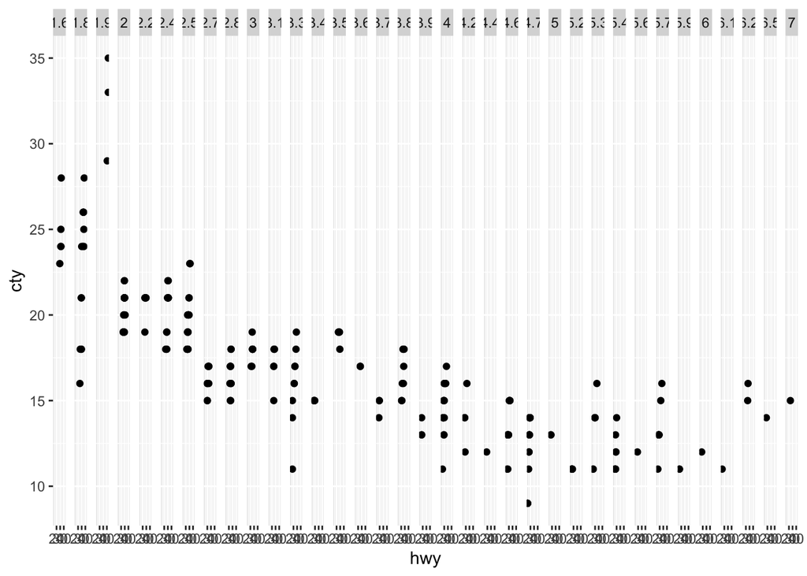

```r
# Facet a continuous variable
ggplot(data = mpg) +
  geom_point(mapping = aes(x = hwy, y = cty)) +
  facet_grid(cols = vars(displ))
```

*Interpretation*  
facet_grid() will convert the continuous variable into categorical variable, and plot each type of combination. However, since we’re faceting based on a continuous variable, there will be too many combinations, making the plot unreadable.

### 2.3.3

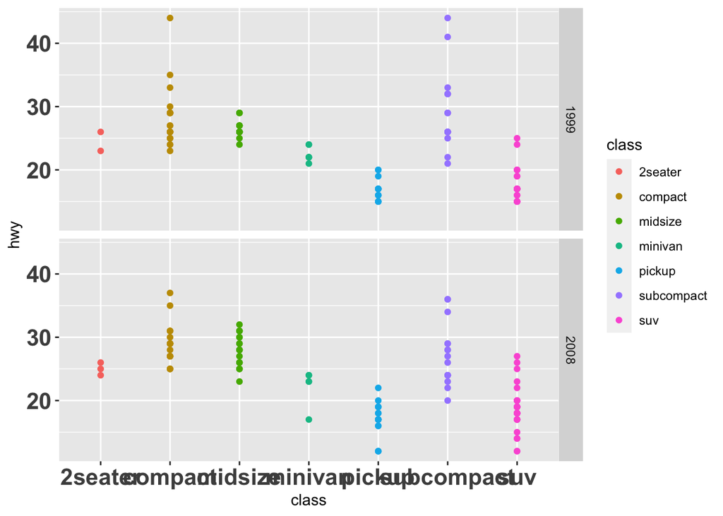

```r
# Reproduce the graph
ggplot(data = mpg) +
  geom_point(mapping = aes(x = class, y = hwy,color = class)) +
  facet_grid(rows = vars(year))+
  theme(axis.text = element_text(size = 16,face = "bold"))
```

### 2.3.4

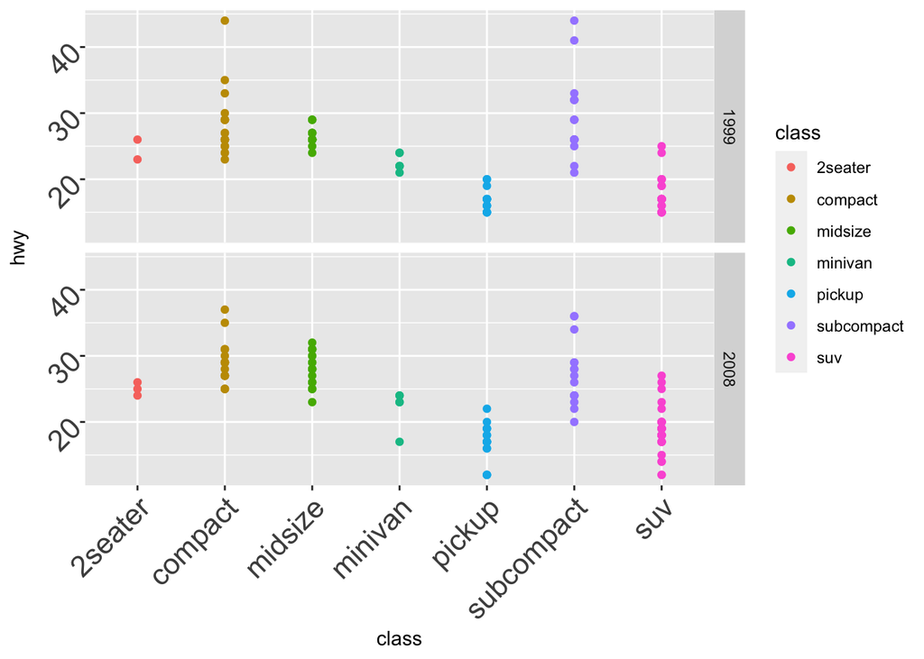

```r
# Reproduce the graph
ggplot(data = mpg) +
  geom_point(mapping = aes(x = class, y = hwy,color = class)) +
  facet_grid(rows = vars(year))+
  theme(axis.text = element_text(size = 16,
                                 hjust = 1,angle = 45))
```

```r
# I learned this before so there is no citation
```

### 2.3.5

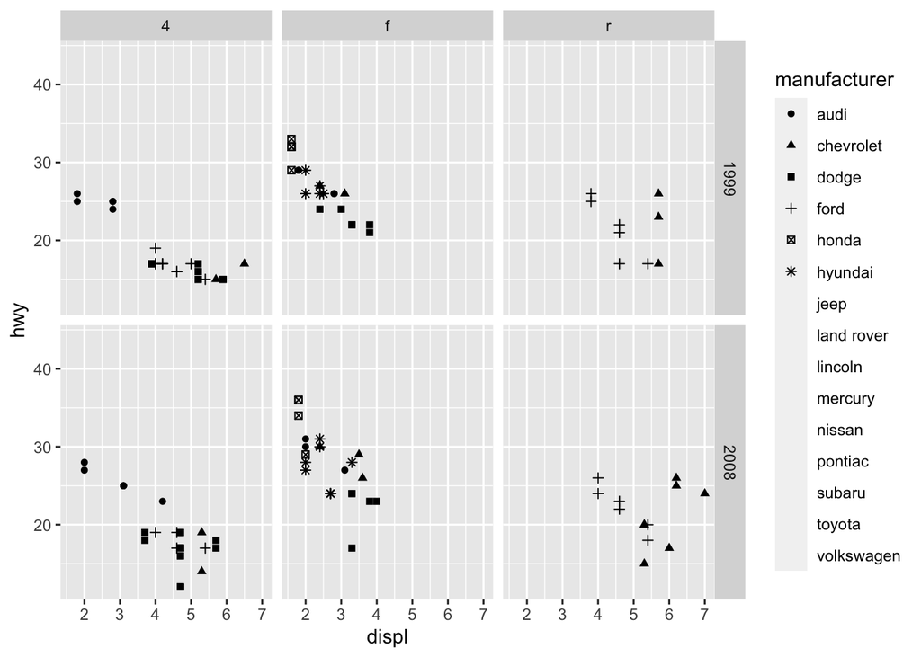

```r
# Reproduce graph
ggplot(data = mpg) +
  geom_point(mapping = aes(x = displ, y = hwy,shape = manufacturer)) +
  facet_grid(rows = vars(year),cols = vars(drv))
```

*Interpretation*  
Because the shape palette can only deal with 6 discrete values at most. If we have more than 6 categories, it would be hard to distinguish the differences. In this case, we have 15 car manufacturers. Therefore, the graph only plots data of cars produced by “audi”,“chevrolet”,“dodge”,“ford”,“honda” or “hyundai”, leading to 112 missing observations.  
*Reference: R help function*

### 2.4 grammar of graphics:geoms

### 2.4 Q1

- Line chart: geom_line
- Boxplot: geom_boxplot
- Area chart: geom_area

### 2.4 Q2

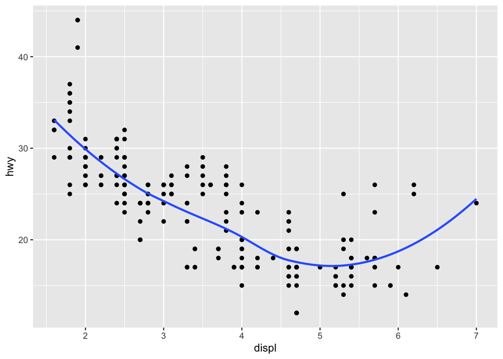

```r
ggplot(data = mpg, mapping = aes(x = displ, y = hwy)) +
  geom_point() +
  geom_smooth(se = FALSE)
```

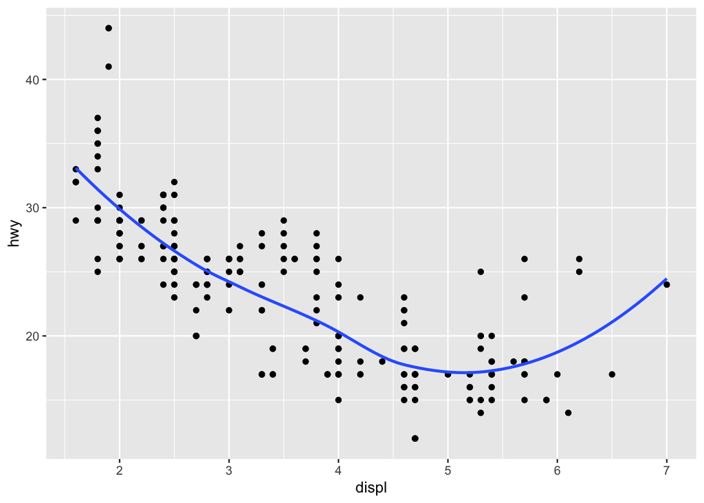

```r
ggplot() +
  geom_point(data = mpg, mapping = aes(x = displ, y = hwy)) +
  geom_smooth(data = mpg, mapping = aes(x = displ, y = hwy), se = FALSE)
```

*Interpretation*  
The two graphs look the same, because they’re using the same data when plotting. In the first part of the code, geom_point() and geom_smooth() will inherit the information in the ggplot bracket, while in the second part of the code each of them include the same information of data within their own brackets. Therefore, the plot will look the same.

### 2.4 Q3

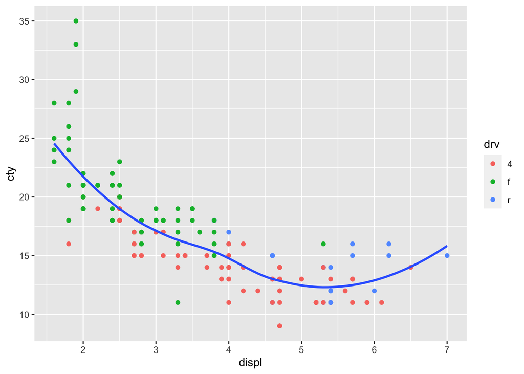

```r
ggplot(data = mpg, mapping = aes(x = displ, y = cty)) +
  geom_point(aes(color = drv)) +
  geom_smooth(se = FALSE)
```

### 2.4 Q4

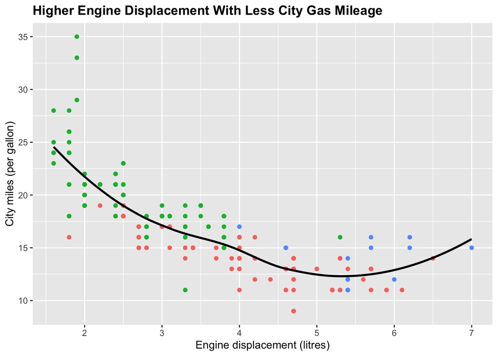

```r
ggplot(data = mpg, mapping = aes(x = displ, y = cty)) +
  geom_point(aes(color = drv)) +
  geom_smooth(color = "black",se = FALSE) + # Change line color
  labs(title = "Higher Engine Displacement With Less City Gas Mileage", # Add title
       x = "Engine displacement (litres)", # Add information about x axis
       y = "City miles (per gallon)") + # Add information about y axis
  theme(plot.title = element_text(face = "bold"),
    legend.position = "none") # Remove legend
```

*Interpretation*  
No. Removing legend will lead to confusion, because we cannot tell what the different colors represent. Other changes will make the plot more informative and readable.(The black line may cover some points but the same situation exists with lines in other colors. Compared to the blue line, black line is more recognizable since it’s different from the legend color)

### 2.4.1.1

- geom_bar() is a kind of bar chart which makes the y values equal to the number of cases in each group. And the bar height is proportional to the number. geom_bar() uses stat_count() by default.
- geom_col() is also a kind of bar chart. However, the y axis of geom_col() plot represents the sum of the value in the data, and the heights of the bars also represent the true value in the data. geom_col() uses stat_identity() by default. *Reference: R Help Function*

### 2.4.1.2

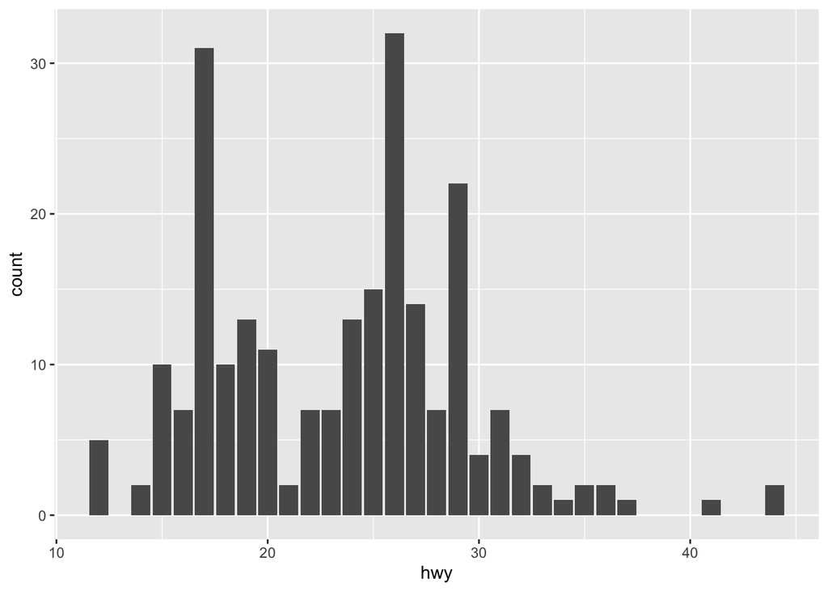

```r
ggplot(data=mpg, aes(x=hwy)) +
  geom_bar()
```

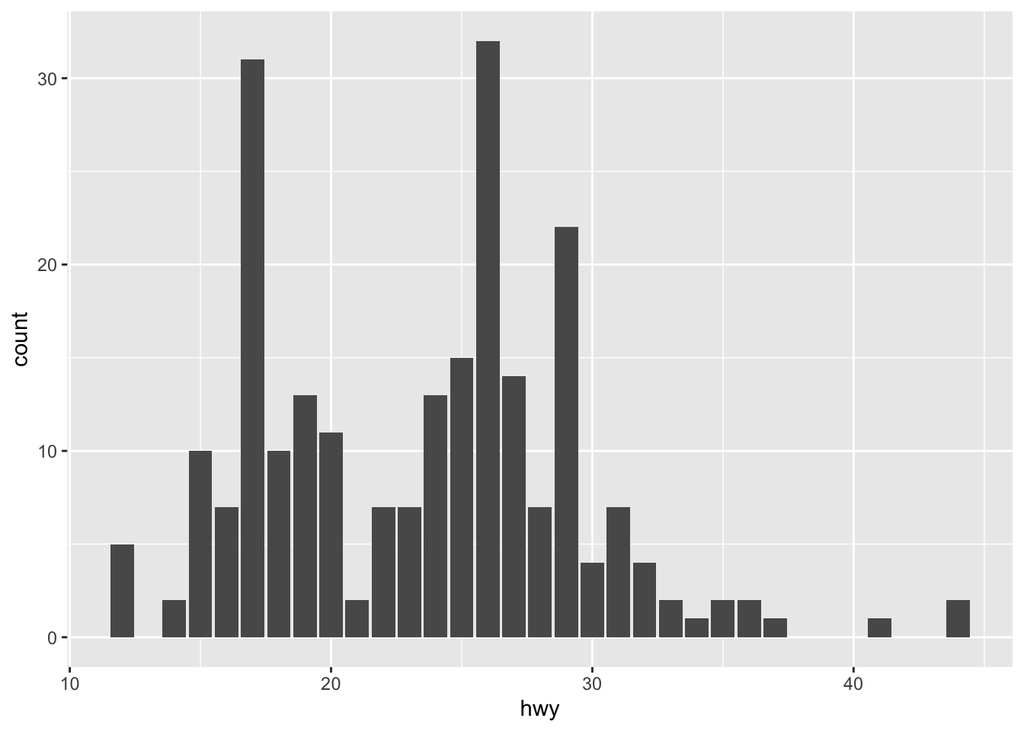

```r
ggplot(data=mpg, aes(x=hwy)) +
  stat_count()
```